# lab_2_MarkovychDenys

Лабораторна робота №2

**Мета:** *Освоїти аналіз складності алгоритмів як технологію на прикладі алгоритмів сортування методами вставляння та бульбашки*

[figure not shown]

Виконав: Маркович Денис група КІ-22-1

3. Обидва методи не ефективні для великої кількості елементів. Зокрема вони обидва мають квадратичну складність O(n^2) у найгіршому та середньому випадках.

4. Реалізація методів сортування:

1) Метод сортування вставкою:

```python
import time

start_time = time.time()

def insertion_sorting(arr):
    for i in range(1, len(arr)):
        key = arr[i]
        n = i - 1
        while n >= 0 and key < arr[n]:
            arr[n + 1] = arr[n]
            n -= 1
        arr[n + 1] = key

my_list = [3, 7, 1, 9, 5, 2, 8]
insertion_sorting(my_list)
print("Відсортований масив: ", my_list)
print("--- %s seconds ---" % (time.time() - start_time))
```

```
Відсортований масив:  [1, 2, 3, 5, 7, 8, 9]
--- 0.0005309581756591797 seconds ---
```

2) Метод сортування бульбашкою:

```python
import time

start_time = time.time()

def bubble_sort(arr):
    n = len(arr)

    for i in range(n):
        for x in range(0, n - i - 1):
            if arr[x] > arr[x + 1]:
                arr[x], arr[x + 1] = arr[x + 1], arr[x]

my_list = [3, 7, 1, 9, 5, 2, 8]
bubble_sort(my_list)
print("Відсортований масив: ", my_list)
print("--- %s seconds ---" % (time.time() - start_time))
```

```
Відсортований масив:  [1, 2, 3, 5, 7, 8, 9]
--- 0.0025811195373535156 seconds ---
```

5. Реалізація поставленої задачі

```
Масив на (5) елементів
Сортування вставкою: 0.000003 секунди середнього часу
Сортування бульбашкою: 0.000005 секунди середнього часу

Масив на (10) елементів
Сортування вставкою: 0.000009 секунди середнього часу
Сортування бульбашкою: 0.000015 секунди середнього часу

Масив на (50) елементів
Сортування вставкою: 0.000087 секунди середнього часу
Сортування бульбашкою: 0.000199 секунди середнього часу

Масив на (100) елементів
Сортування вставкою: 0.000407 секунди середнього часу
Сортування бульбашкою: 0.000800 секунди середнього часу

Масив на (500) елементів
Сортування вставкою: 0.004409 секунди середнього часу
Сортування бульбашкою: 0.009637 секунди середнього часу

Масив на (1000) елементів
Сортування вставкою: 0.009223 секунди середнього часу
Сортування бульбашкою: 0.038516 секунди середнього часу

Масив на (2000) елементів
Сортування вставкою: 0.038793 секунди середнього часу
Сортування бульбашкою: 0.152541 секунди середнього часу

Масив на (3000) елементів
Сортування вставкою: 0.086800 секунди середнього часу
Сортування бульбашкою: 0.346282 секунди середнього часу

Масив на (4000) елементів
Сортування вставкою: 0.152640 секунди середнього часу
Сортування бульбашкою: 0.615685 секунди середнього часу

Масив на (5000) елементів
Сортування вставкою: 0.241439 секунди середнього часу
Сортування бульбашкою: 0.959701 секунди середнього часу

Масив на (10000) елементів
Сортування вставкою: 1.003258 секунди середнього часу
Сортування бульбашкою: 3.877733 секунди середнього часу

Масив на (20000) елементів
Сортування вставкою: 3.941902 секунди середнього часу
Сортування бульбашкою: 15.461097 секунди середнього часу

Масив на (50000) елементів
Сортування вставкою: 24.516069 секунди середнього часу
Сортування бульбашкою: 97.785905 секунди середнього часу

Масив на (100000) елементів
Сортування вставкою: 98.439276 секунди середнього часу
Сортування бульбашкою: 392.849192 секунди середнього часу
```

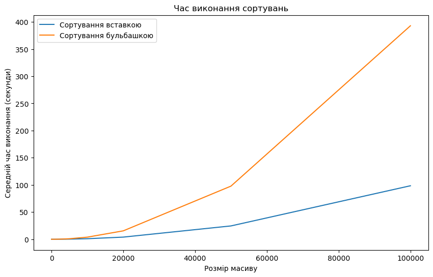

```python
import timeit
import random
import matplotlib.pyplot as plt

sizes = [5, 10, 50, 100, 500, 1000, 2000, 3000, 4000, 5000, 10000, 20000, 50000, 100000]
num_trials = 10  # Кількість прогонів для кожного розміру масиву

def bubble_sort(arr):
    n = len(arr)
    for i in range(n):
        for x in range(0, n - i - 1):
            if arr[x] > arr[x + 1]:
                arr[x], arr[x + 1] = arr[x + 1], arr[x]
    return arr

def insertion_sorting(arr):
    for i in range(1, len(arr)):
        key = arr[i]
        n = i - 1
        while n >= 0 and key < arr[n]:
            arr[n + 1] = arr[n]
            n -= 1
        arr[n + 1] = key
    return arr

insertion_times = []
bubble_times = []

for size in sizes:
    array = random.sample(range(1, size + 1), size)

    print(f"\nМасив на ({size}) елементів")

    insertion_sorted_array = insertion_sorting(array.copy())
    insertion_time = timeit.timeit(stmt=lambda: insertion_sorting(array.copy()), number=num_trials)
    insertion_avg_time = insertion_time / num_trials
    insertion_times.append(insertion_avg_time)
    print(f"Сортування вставкою: {insertion_avg_time:.6f} секунди середнього часу")


    bubble_sorted_array = bubble_sort(array.copy())
    bubble_time = timeit.timeit(stmt=lambda: bubble_sort(array.copy()), number=num_trials)
    bubble_avg_time = bubble_time / num_trials
    bubble_times.append(bubble_avg_time)
    print(f"Сортування бульбашкою: {bubble_avg_time:.6f} секунди середнього часу")


plt.figure(figsize=(10, 6))
plt.plot(sizes, insertion_times, label='Сортування вставкою')
plt.plot(sizes, bubble_times, label='Сортування бульбашкою')
plt.xlabel('Розмір масиву')
plt.ylabel('Середній час виконання (секунди)')
plt.title('Час виконання сортувань')
plt.legend()
plt.show()
```

Відповідь на Контрольні запитання

1) O - нотація вказує на межу часової або просторової складності алгоритму.  
Якщо функція f(n)=O(g(n)), то f(n) обмежується зверху константою, помноженою на g(n).  
Ω - нотація вказує на нижню межу часової або просторової складності алгоритму.  
Якщо функція f(n)=Ω(g(n)), то f(n) обмежується знизу константою, помноженою на g(n).

2) Сортування методом вставки має оптимальну часову складність вже у випадку, коли масив відсортований.  
Такий випадок відомий як "найсприятливіша умова" для алгоритму сортування методом вставки.  
Оптимальна часова складність у цьому випадку дорівнює O(n), де "n" - кількість елементів у масиві.

3) Ефективний алгоритм - основна ідея алгоритму полягає в тому щоб досягти максимально можливого результату при мінімальній витраті ресурсів.  
Основні критерії ефективності алгоритму включають:  
- Часова складність  
- Просторова складність  
- Робота в найгіршому випадку  
- Спрощення та оптимізація коду  
- Маштабованість

4) Поняття головного параметру задачі вказує на розмір вхідних даних, які обробляє алгоритм. Він визначає розмірність задачі та впливає на час чи ресурси, які потрібні для вирішення цієї задачі.  
Функція часової складності має вигляд: $F(N)=N^3+7N^2-14N$.  
Щоб виразити асимптотичну складність використовуємо "O", домінантом є $N^3$,  
звідси можемо надати відповідь, що асимптотична складність буде записана, як $O(N^3)$